# Capstone Milestone Report

An initial analysis of text data and natural language processing

Ian Dobbs

2023-10-20

## Executive Summary

This report is an initial analysis of text data and natural language processing. The purpose is to demonstrate that the text files have been successfully loaded and to show some summary statistics that illustrate the dimensions and word frequencies. It will explain how this contributes to preparations for creating the prediction algorithm and Shiny app that are the ultimate goal of this project. The processing will examine only the English database by executing the following steps:

- data loading
- summary statistics - word and line counts
- a representative random sampling of the text data
- profanity filtering
- data cleansing
- exploratory analysis to understand the frequencies of words and pairs
- consideration of next steps

## Loading the data

Loading the English-US text files only

| en_US.blogs.txt |
| --- |
| en_US.news.txt |
| en_US.twitter.txt |

Summary statistics - Word Count by file

|  | Number of Words |
| --- | --- |
| en_US.blogs.txt | 37334131 |
| en_US.news.txt | 2643969 |
| en_US.twitter.txt | 30373543 |

Summary statistics - Line Count by file

|  | Number of Lines |
| --- | --- |
| en_US.blogs.txt | 899288 |
| en_US.news.txt | 77259 |
| en_US.twitter.txt | 2360148 |

## Sampling - a representative random sample of the text data

It is not necessary to use all of the data to build a predictive model. It is possible that a smaller number of randomly selected rows can produce an accurate approximation versus using all the data. There are also significant memory and system processing constraints that mean it is not possible to use all of the data. For the purposes of this analysis a representative random sample will be taken from each text file and the results combined to create a new sample file for further analysis and processing. The process will take a sample equivalent to 1% of the available data.

```
## Text sample data saved to output_sample.txt
```

The text sample data contains **33367** lines and **704615** words.

## Profanity Filtering

To prevent the prediction of offensive language in the model algorithm and Shiny app it will be removed from the corpus. For this analysis a new list has been created taking as its source Ipsos-MORI research for Ofcom (the UK regulator) published in September 2021 and titled [Public attitudes to offensive language on TV and Radio: Quick Reference Guide](https://www.ofcom.org.uk/__data/assets/pdf_file/0020/225335/offensive-language-quick-reference-guide.pdf) The file of offensive words has been compared to the text sample data and any matches have been removed.

```
## Filtered text saved to output_filtered.txt
```

## Data Cleansing

The next step is tokenization of the filtered text. Tokenization is the process of breaking down the sequence of text in the sample into smaller units, most often words or sub-words, called tokens. For the purposes of this project, tokenization is a crucial step because it enables the analysis of text by converting it into a format that can be processed more easily. Identifying tokens such as words, punctuation and numbers makes cleansing the document far more manageable. For this report the following have been removed from the sample text data:

- numbers
- punctuation and special characters
- stop words - words considered to be of little value in text analysis because they are highly frequent in most documents and do not carry significant information. e.g.”the”, “and”, “is”, “in”, “it”, “to”, “of”
- white space
- contractions - removing the apostrophe and/or space from contractions e.g. “don t”, “can t”, “doesn t”, “didn t”

```
## Filtered & cleaned text saved to output_cleaned.txt
```

The filtered and cleaned text sample data contains **33343** lines and **385911** words.

This has reduced the number of words in the corpus by 45%.

## Exploratory Data Analysis - understanding frequencies of words and word pairs

The filtered and cleaned text is called a corpus in text mining and natural language processing (NLP) and refers to a large and structured collection of text documents. The corpus is the fundamental resource used in various text analysis tasks, and the next phase of the project, language modelling.

The first text analysis task to be carried out is to report on n-grams. An n-gram is a contiguous sequence of n items from a given sample of text. In the context of text mining and natural language processing for this analysis, these “items” are words. N-grams are a fundamental concept in text analysis and language modelling and are used to understand the structure and patterns within a sequence of text. The “n” in “n-gram” represents the number of items in each sequence.

### Unigrams - single words

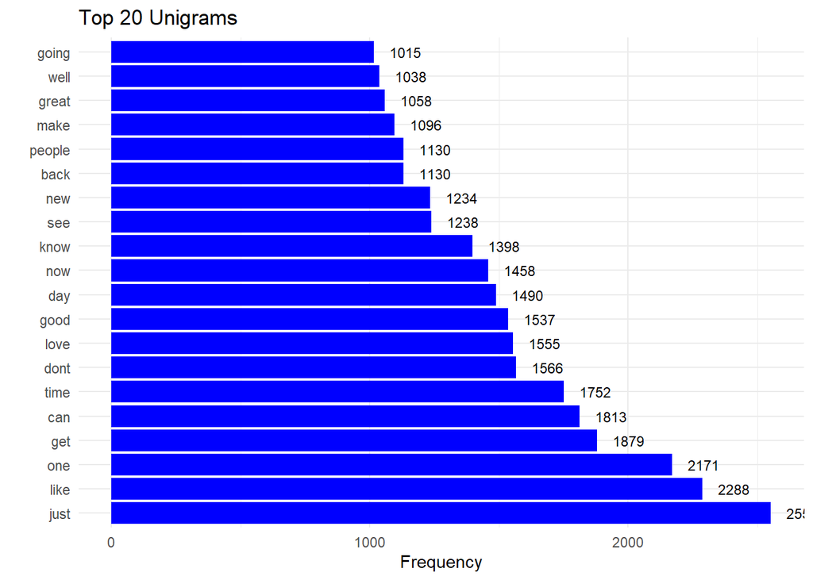

Figure 1: the frequency of single words in the sampled corpus

### Bigram - word pairs

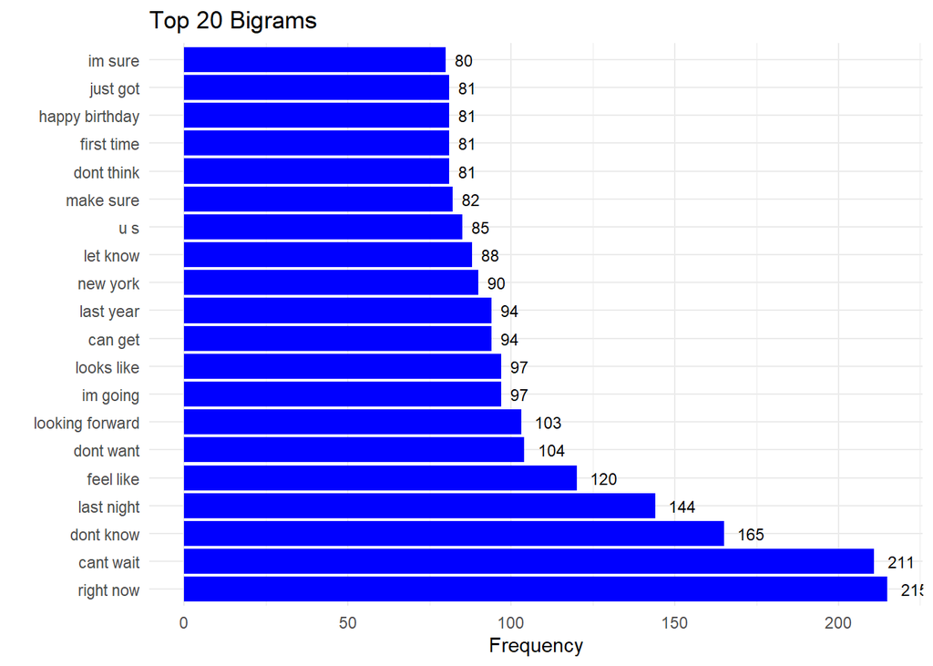

Figure 2: the frequency of two adjacent words in the sampled corpus

### Trigram - word triplets

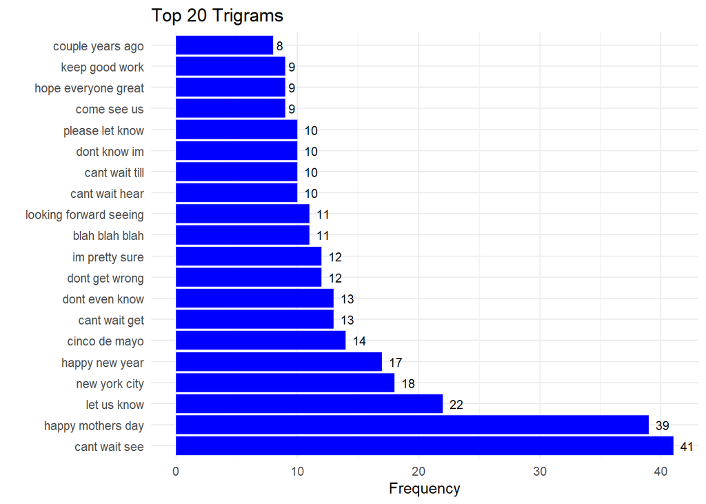

Figure 3: the frequency of three adjacent words in the sampled corpus

## Next steps

The ultimate goal of the capstone project is a predictive algorithm and shiny app to predict the next word from an input word or phrase. The corpus produced for this report serves as the raw material for building and training the text analysis model and algorithm in the next stage of the project. However, a number of challenges still need to addressed and will require fine-tuning. Some potential challenges in the next phase will be:

- inaccurate data, spelling or grammar
- limited coverage
- too small a corpus
- overfitting
- missing context
- language variability
- model bias

# Appendix A: All R code for this report

```r
knitr::opts_chunk$set(echo = TRUE, warning = FALSE, message = FALSE,
                      fig.cap = TRUE, fig.align = "center",
                      fig.path="figures/", options(scipen=999))
knitr::opts_current$get('label')
#load libraries
library(parallel)
library(tm)
library(kableExtra)
library(stringi)
library(stopwords)
library(qdapRegex)
library(RWeka)
library(ggplot2)
# locate and download the dataset
fileurl <-  "https://d396qusza40orc.cloudfront.net/dsscapstone/dataset/Coursera-SwiftKey.zip"
download.file(fileurl, destfile = "Coursera-SwiftKey.zip", method = "curl")
unzip("Coursera-SwiftKey.zip")
# Use parallel processing to speed up processing obtain the number of words in each text file.

# Set the directory where your text files are located
file_directory <- "C:/Users/44772/Documents/Rstudio_projects/datasciencecoursera/dsscapstone/final/en_US/"

# List all text files in the directory
text_files <- list.files(file_directory, pattern = ".txt", full.names = TRUE)

# Create a function to count words in the text
count_words <- function(text) {
        words <- unlist(strsplit(text, "\\s+"))
        return(length(words))
}

# Initialize a cluster for parallel processing (I have 8 cores in total and keep 1 for the OS)
cl <- makeCluster(detectCores()-1)

# Export the necessary variables and functions to the workers
clusterExport(cl, c("count_words"))

# Load and count words in parallel with parLapply
results <- parLapply(cl, text_files, function(file) {
        text <- tolower(readLines(file, warn = FALSE, encoding = "UTF-8"))

        return(count_words(text))
})

# Stop the parallel cluster and release resources
stopCluster(cl)

# Combine the results into a single data frame
result_names <- basename(text_files)
result_vectorW <- data.frame(setNames(results, result_names))
result_vectorW <- t(result_vectorW)
# Print or save the results
kable(result_names, format = "markdown", caption = "Loading the English-US text files only", col.names = NULL)
kable(result_vectorW, format = "markdown", caption = "Summary statistics - Word Count by file", col.names = c("Number of Words"))
# Create a function to count lines in a text file
count_lines <- function(file_path) {
        lines <- length(readLines(file_path, warn = FALSE, encoding = "UTF-8"))
        return(lines)
}

# Initialize a cluster for parallel processing
cl <- makeCluster(detectCores()-1)

# Export the necessary variables and functions to the workers
clusterExport(cl, c("count_lines"))

# Count lines in parallel
results <- parSapply(cl, text_files, function(file) {
        return(count_lines(file))
})

# Stop the parallel cluster
stopCluster(cl)

# Combine the results into a named vector
result_names <- basename(text_files)
result_vectorL <- setNames(results, result_names)

# Print or save the results
kable(as.data.frame(result_vectorL), format = "markdown", caption = "Summary statistics - Line Count by file", col.names = c("Number of Lines"))
# set seed for reproducibility
set.seed(1962)

# List of file paths for the three separate text files
file_paths <- c("C:/Users/44772/Documents/Rstudio_projects/datasciencecoursera/dsscapstone/final/en_US/en_US.blogs.txt",
                "C:/Users/44772/Documents/Rstudio_projects/datasciencecoursera/dsscapstone/final/en_US/en_US.news.txt",
                "C:/Users/44772/Documents/Rstudio_projects/datasciencecoursera/dsscapstone/final/en_US/en_US.twitter.txt")

# Function to calculate the total number of non-empty lines in a file
get_total_non_empty_lines <- function(file_path) {
        lines <- readLines(file_path, warn = FALSE)
        non_empty_lines <- lines[nchar(lines) > 0]
        return(length(non_empty_lines))
}

# Calculate the total number of non-empty lines in each file
total_non_empty_lines <- sapply(file_paths, get_total_non_empty_lines)

# Calculate the total non-empty lines across all files
total_non_empty_lines_all <- sum(total_non_empty_lines)

# Define the desired sample size as a proportion of the total non-empty lines
sample_proportion <- 0.01  # 1% of the total non-empty lines

# Calculate the sample size for each file
sample_size_per_file <- round(sample_proportion * total_non_empty_lines)

# Initialize an empty list to store sampled lines from each file
sampled_lines_list <- list()

# Loop through each file and sample lines while ignoring empty lines
for (i in 1:length(file_paths)) {
        file_path <- file_paths[i]
        num_non_empty_lines <- total_non_empty_lines[i]
        sample_size <- sample_size_per_file[i]

        # Read all lines while ignoring empty lines
        lines <- readLines(file_path, warn = FALSE)
        non_empty_lines <- lines[nchar(lines) > 0]

        # Sample lines proportionally to the non-empty lines
        sampled_indices <- sample(1:num_non_empty_lines, size = sample_size)

        # Select the sampled lines from non-empty lines
        sampled_lines <- non_empty_lines[sampled_indices]

        sampled_lines_list[[file_path]] <- sampled_lines
}

# Combine the sampled lines into a single dataset
combined_lines <- unlist(sampled_lines_list)

# Specify the output file
output_file <- "output_sample.txt"

# Write the combined lines to the output file
writeLines(combined_lines, con = output_file)
cat("Text sample data saved to", output_file, "\n")
# Create a list of profanity words

profanity_list <- readLines("C:/Users/44772/Documents/Rstudio_projects/datasciencecoursera/dsscapstone/ofcomwords.txt",
                            encoding = "UTF-8", skipNul = TRUE)

# Specify the path to the input/output text file

input_file <- "C:/Users/44772/Documents/Rstudio_projects/datasciencecoursera/dsscapstone/output_sample.txt"
output_file <- "output_filtered.txt"

# Read the text from the input file
text <- tolower(readLines(input_file, warn = FALSE))

# Tokenize the text into words
words <- unlist(strsplit(text, "\\s+"))

# Initialize a count dictionary for profanity words
profanity_count <- rep(0, length(profanity_list))
names(profanity_count) <- profanity_list
```

```r
# Count the occurrences of profanity words
for (word in words) {
        if (word %in% profanity_list) {
                profanity_count[word] <- profanity_count[word] + 1
        }
}

# Create a data frame for analysis
profanity_data <- data.frame(Word = names(profanity_count), Count = unname(profanity_count))

# Sort the data frame in descending order by count
profanity_data <- profanity_data[order(profanity_data$Count, decreasing = TRUE), ]

# Display the sorted data frame
# print(profanity_data)

# Decide whether to remove profanity based on the counts greater than 0
if (sum(profanity_count) > 0) {
        # Create a function to replace profanity words with empty strings
        replace_profanity <- function(text) {
                for (word in profanity_list) {
                        text <- gsub(paste0("\\b", word, "\\b"), "", text, ignore.case = TRUE)
                }
                return(text)
        }

        # Apply the profanity removal function to the text
        filtered_text <- replace_profanity(text)

        # Write the filtered text to the output file
        writeLines(filtered_text, con = output_file)

        cat("Filtered text saved to", output_file, "\n")

} else {
        # No profanity detected, proceed with the original text
        cat("No profanity detected. Continue with the original text:\n", text)
}
# Clean sample text

# # Specify the path to the input/output text file
input_file <- "C:/Users/44772/Documents/Rstudio_projects/datasciencecoursera/dsscapstone/output_filtered.txt"
output_file <- "output_cleaned.rds"
output_file1 <- "output_cleaned.txt"

# Read the text from the input file
text <- tolower(readLines(input_file, warn = FALSE))

# Remove/replace/extract non-words (Anything that's not a letter or apostrophe;
# also removes multiple white spaces) from a string.

text <- rm_non_words(text)

# Define a function to clean text
clean_text <- function(text) {
        # Create a Corpus
        corpus <- Corpus(VectorSource(text))
        contractions <- content_transformer(function(x, pattern) gsub(pattern, "", x))
        corpus <- tm_map(corpus, contractions, "'")
        dont <- content_transformer(function(x, pattern) gsub(pattern, "dont", x))
        corpus <- tm_map(corpus, dont, "don t")
        cant <- content_transformer(function(x, pattern) gsub(pattern, "cant", x))
        corpus <- tm_map(corpus, cant, "can t")
        doesnt <- content_transformer(function(x, pattern) gsub(pattern, "doesnt", x))
        corpus <- tm_map(corpus, doesnt, "doesn t")
        didnt <- content_transformer(function(x, pattern) gsub(pattern, "didnt", x))
        corpus <- tm_map(corpus, didnt, "didn t")

        # Remove numbers
        corpus <- tm_map(corpus, removeNumbers)
        # Remove punctuation
        corpus <- tm_map(corpus, removePunctuation)
        # Remove common English stop words
        corpus <- tm_map(corpus, removeWords, stopwords("en"))
        # Strip whitespace
        corpus <- tm_map(corpus, stripWhitespace)
        # Remove empty documents
        corpus <- corpus[!(sapply(corpus, function(x) length(unlist(strsplit(as.character(x), " "))) == 0))]
        # Combine the cleaned text into a single document
        cleaned_text <- unlist(corpus)

        return(cleaned_text)
}

# Clean the text
cleaned_text <- clean_text(text)

# Specify the output file path for the cleaned text
output_file <- "output_cleaned.rds"
output_file1 <- "output_cleaned.txt"

# Save the cleaned text data to the RDS file
saveRDS(cleaned_text, file = output_file)
writeLines(cleaned_text, con = output_file1)

# Print a message indicating where the RDS file is saved
cat("Filtered & cleaned text saved to", output_file1, "\n")
# create tokenizer functions
unigram_tokenizer <- function(x) NGramTokenizer(x, Weka_control(min = 1, max = 1))
bigram_tokenizer <- function(x) NGramTokenizer(x, Weka_control(min = 2, max = 2))
trigram_tokenizer <- function(x) NGramTokenizer(x, Weka_control(min = 3, max = 3))
# the text data is in a file, use readLines() to read it into a character vector.
input_file <- "C:/Users/44772/Documents/Rstudio_projects/datasciencecoursera/dsscapstone/output_cleaned.txt"
cleaned_text <- tolower(readLines(input_file, warn = FALSE))
# Create a corpus from cleaned text
corpus <- VCorpus(VectorSource(cleaned_text))
# create term document matrix for the corpus
unigramtdm <- TermDocumentMatrix(corpus, control = list(tokenize = unigram_tokenizer))
# eliminate sparse terms for each n-gram and get frequencies of n-grams
# to remove terms that occur in less than 1% of documents
uFreq <- sort(rowSums(as.matrix(removeSparseTerms(unigramtdm, 0.99))), decreasing = TRUE)
uFreq <- data.frame(word = names(uFreq), freq = uFreq)
# generate plot
ggplot(uFreq[1:20,], aes(x = reorder(word, -freq), y = freq)) +
        geom_bar(stat = "identity", fill = "blue") +
        geom_text(aes(label = freq ), hjust = -0.5, size = 3) +
        coord_flip() +
        labs(title = "Top 20 Unigrams", x = "", y = "Frequency") +
        theme_minimal()
bigramtdm <- TermDocumentMatrix(corpus, control = list(tokenize = bigram_tokenizer))
# to remove terms that occur in less than 0.1% of documents
bFreq <- sort(rowSums(as.matrix(removeSparseTerms(bigramtdm, 0.999))), decreasing = TRUE)
bFreq <- data.frame(word = names(bFreq), freq = bFreq)
ggplot(bFreq[1:20,], aes(x = reorder(word, -freq), y = freq)) +
        geom_bar(stat = "identity", fill = "blue") +
        geom_text(aes(label = freq ), hjust = -0.5, size = 3) +
        coord_flip() +
        labs(title = "Top 20 Bigrams", x = "", y = "Frequency") +
        theme_minimal()
trigramtdm <- TermDocumentMatrix(corpus, control = list(tokenize = trigram_tokenizer))
# to remove terms that occur in less than 0.01% of documents
tFreq <- sort(rowSums(as.matrix(removeSparseTerms(trigramtdm, 0.9999))), decreasing = TRUE)
tFreq <- data.frame(word = names(tFreq), freq = tFreq)
ggplot(tFreq[1:20,], aes(x = reorder(word, -freq), y = freq)) +
        geom_bar(stat = "identity", fill = "blue") +
        geom_text(aes(label = freq ), hjust = -0.5, size = 3) +
        coord_flip() +
        labs(title = "Top 20 Trigrams", x = "", y = "Frequency") +
        theme_minimal()
```